# 幸福指數研究

claire

2018年7月30日

#### 先取得資料，將兩筆資料合併，然後將複雜的資料名稱簡易化

```r
library(dplyr)
```

```r
library(ggplot2)
warning=FALSE
#記得要先設定好工作路徑跟相對檔名(點選 more 裡的 set as working directory)

# Read in data files from `open-data` and `world-happiness` datasets

open_data <- read.csv("countries.csv", stringsAsFactors=F)
happiness <- read.csv("2015.csv", stringsAsFactors=F)
#stringsAsFactors = FALSE tells R to keep character variables as they are rather than convert to factors, which are a little harder to work with.(不讓r將character 轉成 factor)

# Rename from "Country Name" to just "Country" so it's easier to join
colnames(open_data)[2] <- "Country"
#colnames()可以改column的名字

# Join the two dataset files on "Country"
open_data_happiness <- open_data %>%
  left_join(happiness, by = "Country") %>%
  mutate(Country = factor(Country)) %>%
  # Keep only columns I plan to use
  select(Country, Region, X2015.Score, Happiness.Score, Economy..GDP.per.Capita.,
         Family, Health..Life.Expectancy., Freedom, Trust..Government.Corruption.,
         Generosity, Dystopia.Residual)
#left_join可以藉由兩數據中相同的column來做連接，並且是往左增加
# Give the columns nicer names now that our data is in one dataframe
colnames(open_data_happiness) <- c("Country", "Region", "Openness", "Happiness", "GDP", "Family", "Health", "Freedom", "Trust", "Generosity", "DystopiaResidual")
```

### 將數據的名字重新命名以便閱讀

### 到此為止，已經將數據初步整理

```r
library(formattable)
#formmatable可將數據格式化，如百分比，逗號，貨幣，會計和科學，並用表格呈現，是一種易於閱讀的方式
#將資料依開放程度排名，並四捨五入資料至小數第二位，再選出前十
open_data_happiness%>%
  arrange(desc(Openness))%>%
  #mutate_each中的計算會套用至每一行column，用round四捨五入至小數點第二位，其中Country,Region,Opennes 不用被計算
  mutate_each(funs(round(.,2)),-c(Country,Region,Openness))%>%
  head(10)%>%
  formattable(list(
    Openness = color_bar("yellow"),
    Happiness = color_bar("pink"),
    GDP = color_bar("deepskyblue"),
    Family = color_bar("deepskyblue"),
    Health = color_bar("deepskyblue"),
    Freedom = color_bar("deepskyblue"),
    Trust = color_bar("deepskyblue"),
    Generosity = color_bar("deepskyblue"),
    DystopiaResidual = color_bar("deepskyblue")
  ), align = "l"
  )
```

```
## `mutate_each()` is deprecated.
## Use `mutate_all()`, `mutate_at()` or `mutate_if()` instead.
## To map `funs` over a selection of variables, use `mutate_at()`
```

| Country | Region | Openness | Happiness | GDP | Family | Health | Freedom | Trust | Generosity | DystopiaResidual |
| --- | --- | --- | --- | --- | --- | --- | --- | --- | --- | --- |
| Taiwan | Eastern Asia | 78 | 6.30 | 1.29 | 1.08 | 0.88 | 0.40 | 0.08 | 0.25 | 2.32 |
| United Kingdom | Western Europe | 76 | 6.87 | 1.27 | 1.29 | 0.91 | 0.60 | 0.32 | 0.52 | 1.97 |
| Denmark | Western Europe | 70 | 7.53 | 1.33 | 1.36 | 0.87 | 0.65 | 0.48 | 0.34 | 2.49 |
| Colombia | Latin America and Caribbean | 68 | 6.48 | 0.92 | 1.24 | 0.69 | 0.53 | 0.05 | 0.18 | 2.86 |
| Finland | Western Europe | 67 | 7.41 | 1.29 | 1.32 | 0.89 | 0.64 | 0.41 | 0.23 | 2.62 |
| Australia | Australia and New Zealand | 67 | 7.28 | 1.33 | 1.31 | 0.93 | 0.65 | 0.36 | 0.44 | 2.27 |
| Uruguay | Latin America and Caribbean | 66 | 6.49 | 1.06 | 1.21 | 0.81 | 0.60 | 0.25 | 0.23 | 2.32 |
| United States | North America | 64 | 7.12 | 1.39 | 1.25 | 0.86 | 0.55 | 0.16 | 0.40 | 2.51 |
| Netherlands | Western Europe | 64 | 7.38 | 1.33 | 1.28 | 0.89 | 0.62 | 0.32 | 0.48 | 2.47 |
| Norway | Western Europe | 63 | 7.52 | 1.46 | 1.33 | 0.89 | 0.67 | 0.37 | 0.35 | 2.47 |

```r
#表格完成
```

#### 從表格中，被特別標示不同顏色的開放程度和幸福指數可以互相比對關係。從表格中，不太能很明確的看出開放程度與幸福指數有明確的正比趨勢。可推測開放程度並不是決定幸福與否的關鍵

## 探索開放程度與幸福程度之間的確切關係

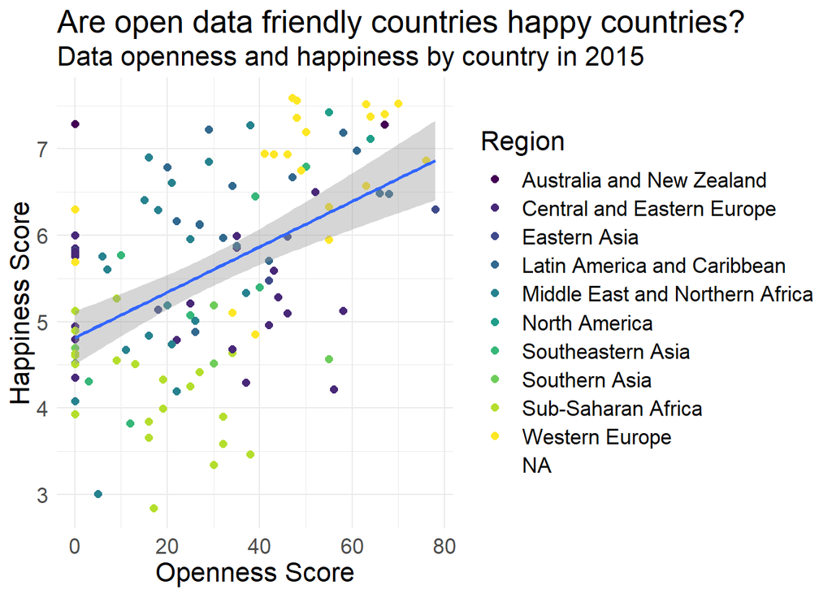

```r
library(ggplot2)
library(ggthemes)
library(viridis)
ggplot(open_data_happiness,
       aes(x = Openness,
           y = Happiness)) +
  geom_point(aes(colour = Region),
             size = 2) +
  #以region為點點顏色的分別基準
  geom_smooth(method="lm") +
  #geom_smooth可以劃出趨勢曲線
  labs(x = "Openness Score",
       y = "Happiness Score",
       title = "Are open data friendly countries happy countries?",
       subtitle = "Data openness and happiness by country in 2015") +
  scale_color_viridis(discrete = T) +
  #scale_color_viridis讓顏色漸層有方向
  theme_minimal() +
  theme(text = element_text(size=16))
```

# 慷慨的國家快樂嗎?

### 分析happines跟Generosity的相關程度

### 先畫圖看看

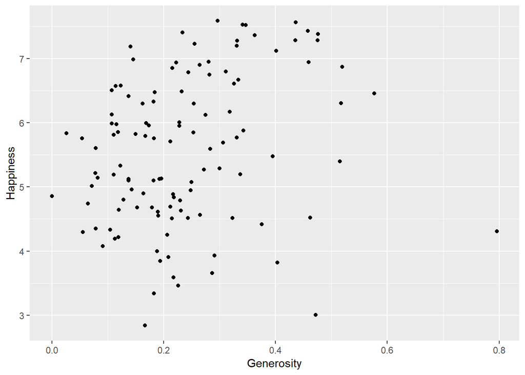

```r
ggplot(data = open_data_happiness, aes(x = Generosity, y = Happiness)) +
  geom_point()
```

#### 好像看不出很明確的關係。因此就整個世界而言，施比受更有福的假設不足以採信。但也許從文化差異的觀點能看出不同文化中，慷慨跟幸福之間的連結

### 比較華人地區跟西方文化地區的慷慨程度

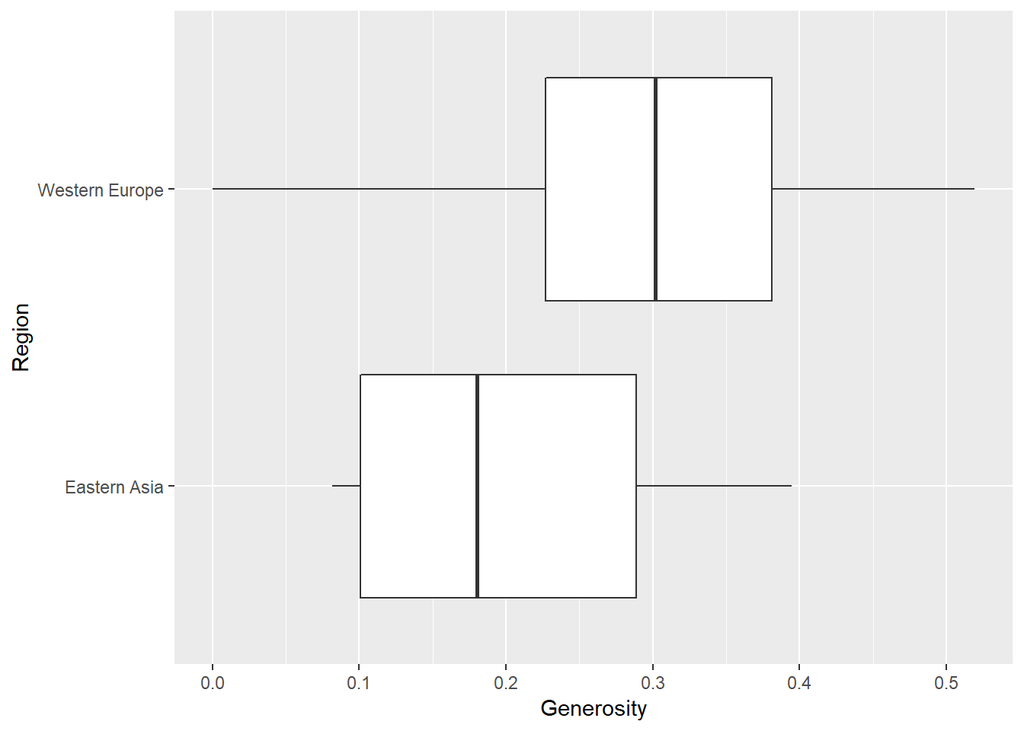

```r
choose<-open_data_happiness%>%filter(Region== "Eastern Asia"|Region=="Western Europe" )
ggplot(choose,aes(x=Region,y=Generosity))+geom_boxplot() +coord_flip()
```

####以下函式計算%95信賴區間

```r
with(choose,
     tapply(Generosity, Region,
            function(x)
              c(mean(x) + c(-2, 2) * sd(x)/sqrt(length(x)))))
```

```
## $`Eastern Asia`
## [1] 0.06435647 0.35436353
##
## $`Western Europe`
## [1] 0.2428644 0.3653946
```

```r
#以下用 t-test 檢驗不同區域是否存在慷慨程度差異
t.test(Generosity ~ Region, data = choose)
```

```
##
##  Welch Two Sample t-test
##
## data:  Generosity by Region
## t = -1.2041, df = 4.1458, p-value = 0.2928
## alternative hypothesis: true difference in means is not equal to 0
## 95 percent confidence interval:
##  -0.3102983  0.1207593
## sample estimates:
##   mean in group Eastern Asia mean in group Western Europe
##                    0.2093600                    0.3041295
```

```r
t.test(Generosity ~ Region, data = choose, var.equal = TRUE)
```

```
##
##  Two Sample t-test
##
## data:  Generosity by Region
## t = -1.2528, df = 22, p-value = 0.2234
## alternative hypothesis: true difference in means is not equal to 0
## 95 percent confidence interval:
##  -0.25165269  0.06211369
## sample estimates:
##   mean in group Eastern Asia mean in group Western Europe
##                    0.2093600                    0.3041295
```

#### 課堂筆記:分布一致才能用回歸

#### 殘差項很大代表挑選的配對model不對，要再換

#### 每個點與估計的點的差異稱作殘差

### 以下觀察Generosity是否與地區有關

#### 先把地區欄位內的順序定下來(order of factors)

```r
open_data_happiness$Region <- factor(open_data_happiness$Region,
                                 levels = c('Eastern Asia',
                                            'Western Europe',
                                            'North America',
                                            'Latin America and Caribbean',
                                            'Central and Eastern Europe',
                                            'Southern Asia',
                                            'Southeastern Asia',
                                            'Middle East and Northern Africa',
                                            'Sub-Saharan Africa',
                                            'Australia and New Zealand'))
```

#### 看不同地區下的慷慨分數平均數

```r
library(Hmisc)
tapply(open_data_happiness$Generosity, open_data_happiness$Region, mean)
```

```
##                    Eastern Asia                  Western Europe
##                       0.2093600                       0.3041295
##                   North America     Latin America and Caribbean
##                       0.4295800                       0.2264253
##      Central and Eastern Europe                   Southern Asia
##                       0.1548943                       0.2841600
##               Southeastern Asia Middle East and Northern Africa
##                       0.4546900                       0.1841189
##              Sub-Saharan Africa       Australia and New Zealand
##                       0.2127724                       0.4553150
```

### 同地區下的慷慨分數平均數，加上信賴區間

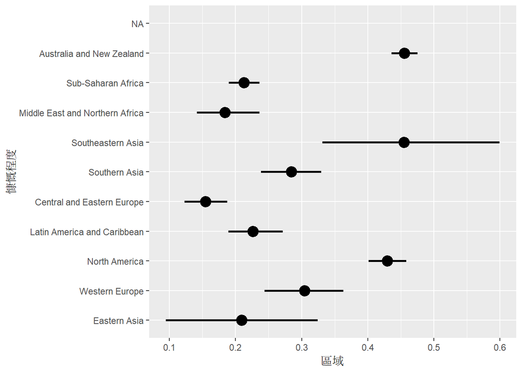

```r
ggplot(data = open_data_happiness,
       aes(x = open_data_happiness$Region, y = open_data_happiness$Generosity)) +
  stat_summary(fun.data = 'mean_cl_boot', size = 1) +
  scale_y_continuous(breaks = seq(0, 1, by = 0.1)) +
  geom_hline(yintercept = mean(open_data_happiness$Generosity) ,
             linetype = 'dotted') +
  labs(x = '慷慨程度', y = '區域')+
  coord_flip()
```

### 在這裡我們推測慷慨的程度可能是快樂差距造成的，畫圖觀察看看

```r
anova(m1 <- lm(Generosity ~ Region, data = open_data_happiness))
```

```
## Analysis of Variance Table
##
## Response: Generosity
##            Df  Sum Sq  Mean Sq F value   Pr(>F)
## Region      9 0.82243 0.091382  8.2619 2.83e-09 ***
## Residuals 108 1.19454 0.011061
## ---
## Signif. codes:  0 '***' 0.001 '**' 0.01 '*' 0.05 '.' 0.1 ' ' 1
```

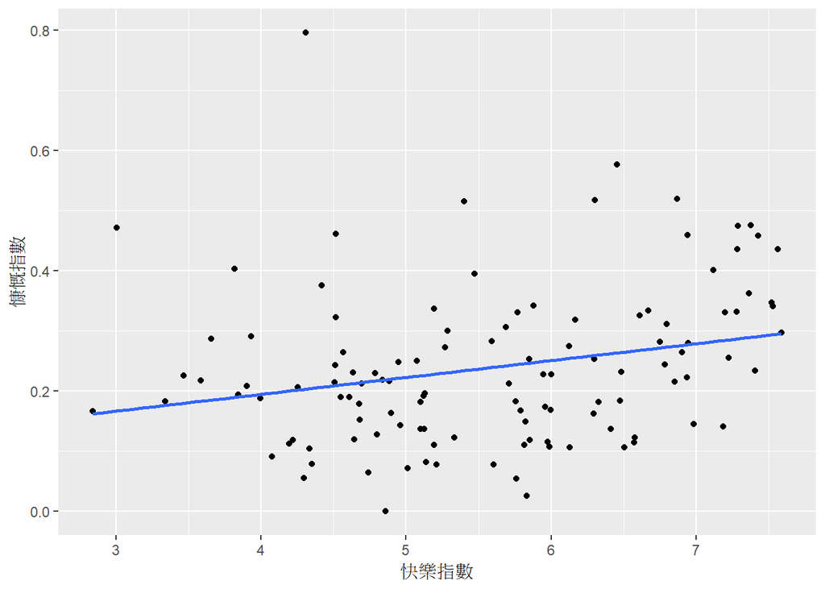

```r
#畫圖
#如果不分區域來看關係
ggplot(data = open_data_happiness, aes(y = Generosity, x = Happiness)) +
  geom_point() +
  stat_smooth(method = 'lm', se = F) +
  labs(x = '快樂指數', y = '慷慨指數')
```

#### 由這張散佈圖可以看出快樂與慷慨指數有著不是非常明顯的正相關關係。

### 如果把區域獨立出來看關係

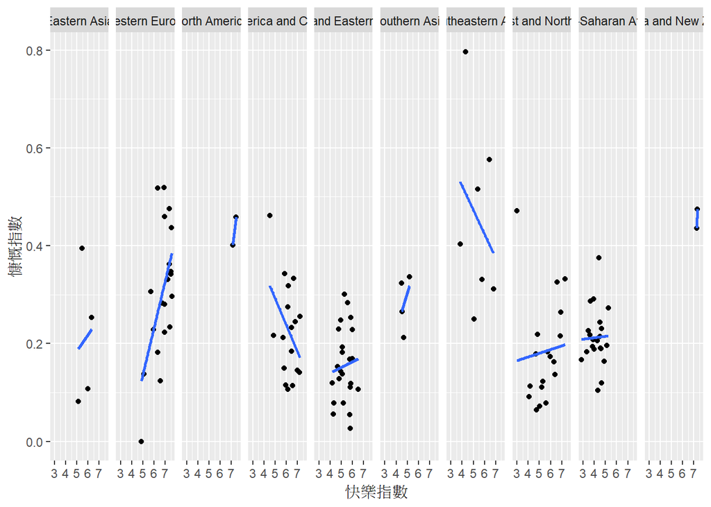

```r
choose1<-open_data_happiness%>%filter(Region!="NA")
ggplot(data = choose1,
       aes(group = Region,
           y = Generosity, x = Happiness)) +
  geom_point() +
  stat_smooth(aes(group = Region,
                  y = Generosity, x = Happiness),
              method = 'lm', se = F) +
  facet_grid( . ~  Region) +
  labs(x = '快樂指數', y = '慷慨指數')
```

### 慷慨程度跟GDP有關嗎

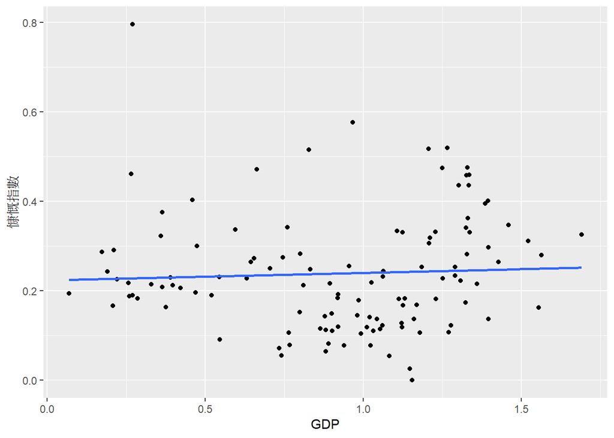

```r
ggplot(data = open_data_happiness, aes(y = Generosity, x = GDP)) +
  geom_point() +
  stat_smooth(method = 'lm', se = F) +
  labs(x = 'GDP', y = '慷慨指數')
```

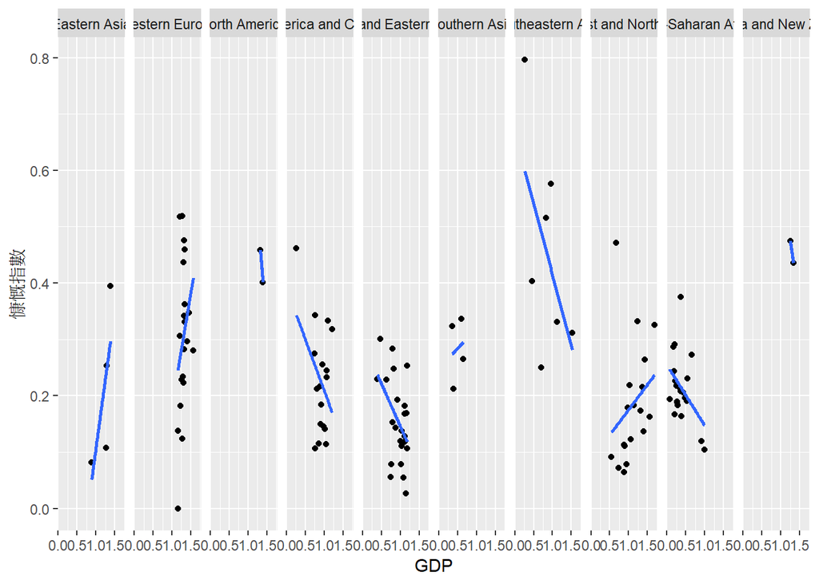

```r
ggplot(data = choose1,
       aes(group = Region,
           y = Generosity, x = GDP)) +
  geom_point() +
  stat_smooth(aes(group = Region,
                  y = Generosity, x = GDP),
              method = 'lm', se = F) +
  facet_grid( . ~  Region) +
  labs(x = 'GDP', y = '慷慨指數')
```

### 跟自由有關嗎

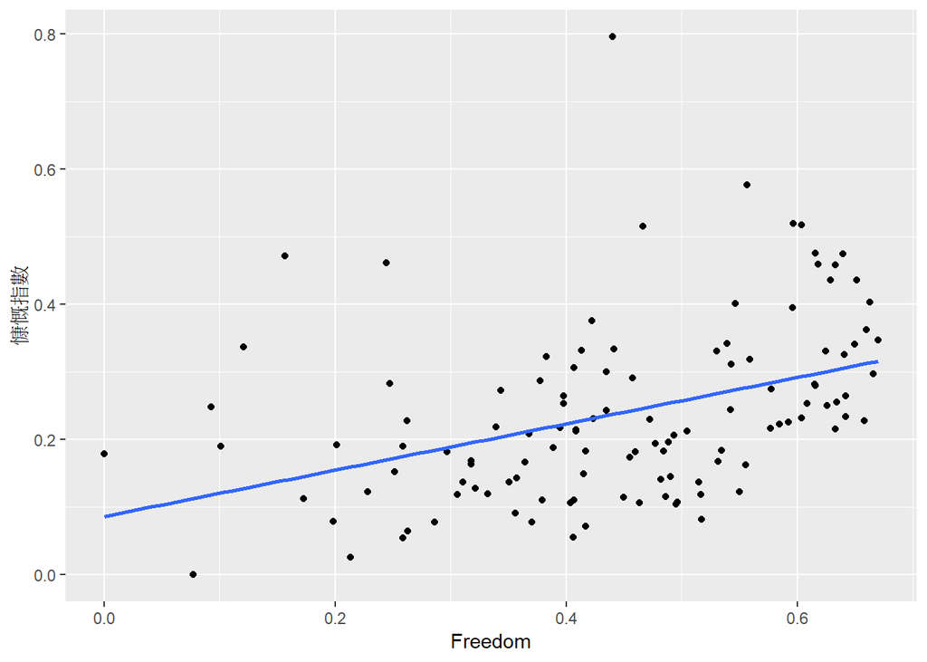

```r
ggplot(data = open_data_happiness, aes(y = Generosity, x = Freedom)) +
  geom_point() +
  stat_smooth(method = 'lm', se = F) +
  labs(x = 'Freedom', y = '慷慨指數')
```

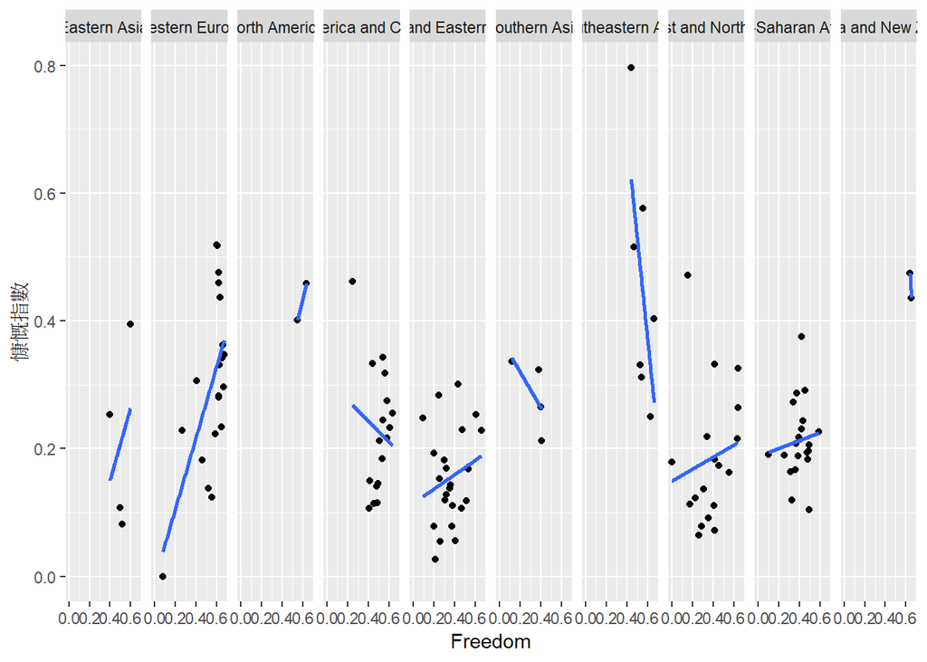

```r
ggplot(data = choose1,
       aes(group = Region,
           y = Generosity, x = Freedom)) +
  geom_point() +
  stat_smooth(aes(group = Region,
                  y = Generosity, x = Freedom),
              method = 'lm', se = F) +
  facet_grid( . ~  Region) +
  labs(x = 'Freedom', y = '慷慨指數')
```

## 利用以下 ANOVA 檢驗假設是否正確

### 把快樂加進模型

```r
anova(m2 <- update(m1, . ~ . +
                     Happiness, data = open_data_happiness))
```

```
## Analysis of Variance Table
##
## Response: Generosity
##            Df  Sum Sq  Mean Sq F value   Pr(>F)
## Region      9 0.82243 0.091382  8.2409 3.12e-09 ***
## Happiness   1 0.00804 0.008036  0.7247   0.3965
## Residuals 107 1.18651 0.011089
## ---
## Signif. codes:  0 '***' 0.001 '**' 0.01 '*' 0.05 '.' 0.1 ' ' 1
```

### 或許不是地區影響而是快樂指數造成(將地區拿掉)

```r
anova(m3 <- update(m2, . ~ . - Region,  data = open_data_happiness))
```

```
## Analysis of Variance Table
##
## Response: Generosity
##            Df  Sum Sq  Mean Sq F value   Pr(>F)
## Happiness   1 0.12356 0.123557  7.5697 0.006889 **
## Residuals 116 1.89342 0.016323
## ---
## Signif. codes:  0 '***' 0.001 '**' 0.01 '*' 0.05 '.' 0.1 ' ' 1
```

### 將 ANOVA 結果做成圖表輸出，先計算一些需要的數據

#### 將結果放在一個list中

#### m1:只有區域 m2:區域跟快樂 m3:只有快樂

```r
res_lm <- lapply(list(m1, m2, m3), summary)
```

### 比較在控制快樂指數下，地區影響的效果

```r
(res_lm[[2]]$r.sq - res_lm[[3]]$r.sq)/res_lm[[2]]$r.sq
```

```
## [1] 0.8512206
```

```r
anova(m3, m2)
```

```
## Analysis of Variance Table
##
## Model 1: Generosity ~ Happiness
## Model 2: Generosity ~ Region + Happiness
##   Res.Df    RSS Df Sum of Sq      F    Pr(>F)
## 1    116 1.8934
## 2    107 1.1865  9   0.70691 7.0833 5.457e-08 ***
## ---
## Signif. codes:  0 '***' 0.001 '**' 0.01 '*' 0.05 '.' 0.1 ' ' 1
```

#### p-value=5.457e-08，差異非常顯著，所以地區有可能是關鍵

### 比較在控制區域下，快樂指數的效果

```r
(res_lm[[2]]$r.sq - res_lm[[1]]$r.sq)/res_lm[[1]]$r.sq
```

```
## [1] 0.009771577
```

```r
anova(m1, m2)
```

```
## Analysis of Variance Table
##
## Model 1: Generosity ~ Region
## Model 2: Generosity ~ Region + Happiness
##   Res.Df    RSS Df Sum of Sq      F Pr(>F)
## 1    108 1.1945
## 2    107 1.1865  1 0.0080365 0.7247 0.3965
```

#### p-value=0.3965，差不多，因此快樂指數不是影響慷慨的主因

### 正式畫圖

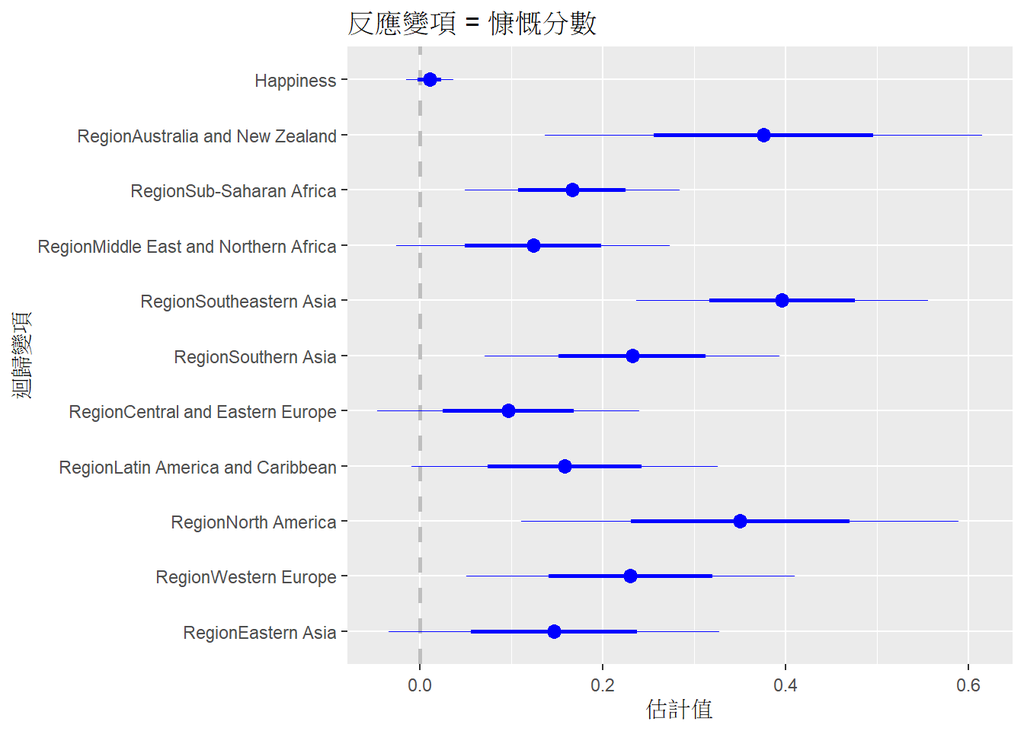

```r
require(coefplot)
m2 <- lm(Generosity ~ Region+Happiness- 1,
         data = open_data_happiness)
coefplot(m2, xlab = '估計值', ylab = '迴歸變項', title = '反應變項 = 慷慨分數')
```

#### 可以看到如果用估計模型的話，慷慨中位數最高的是東南亞，最低的是中歐與東歐。

### 把資料與迴歸分析的預測值、殘差與影響度放進資料

```r
fit_m2 <- data.frame(choose1[, c(10, 2, 4)], fitted = fitted(m2), resid = resid(m2),
                     infl = influence(m2)$hat )
```

### 依區域疊合真實觀測值與預測值

[figure not shown]

```r
ggplot(data = fit_m2, aes(x = Generosity, group = Region )) +
  stat_density(geom = 'path', position = 'identity') +
  stat_density(geom = 'path', position = 'identity', aes(x = fitted)) +
  geom_vline(xintercept = c(with(choose1, tapply(Generosity,Region, mean))), linetype = 'dotted')+
  facet_grid(Region ~ .) +
  scale_x_continuous(breaks = seq(0, 1, by = 100))+
  labs(x = '慷慨分數', y = '機率密度')
```

#### 估計上，紐西蘭與澳洲在偏前端有個尖銳的突起

### 看殘差分配，依區域，檢視常態與變異數同質假設

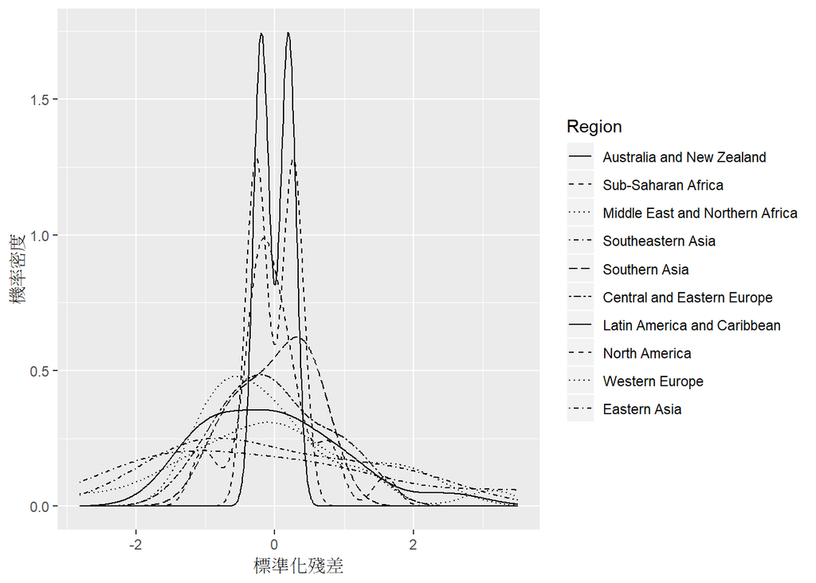

```r
ggplot(data = fit_m2, aes(x = scale(resid)), group = Region ) +
  stat_density(geom = 'path', position = 'identity', aes(linetype = Region)) +
  scale_linetype_manual(values = 10:1) +
  guides(linetype = guide_legend(reverse = TRUE)) +
  labs(x = '標準化殘差', y = '機率密度')
```

#### 可以看到大部分地區的標準化殘差都集中落在-1~1之間，很少超越2

### 看看殘差的 Q-Q 圖，依區域。檢視常態假設

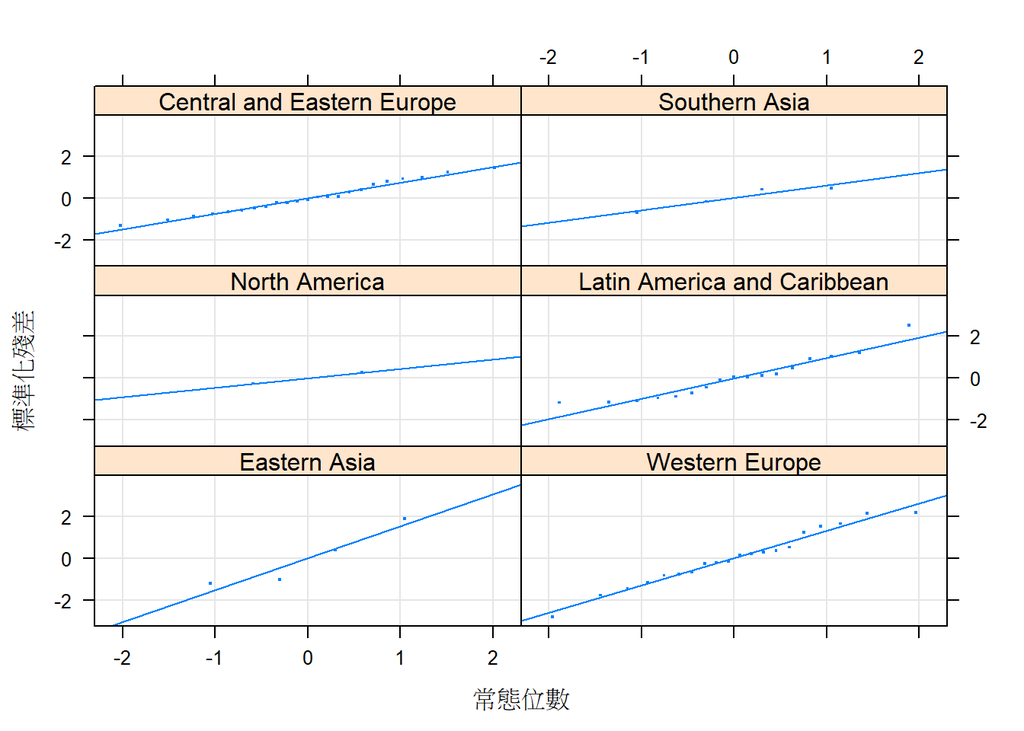

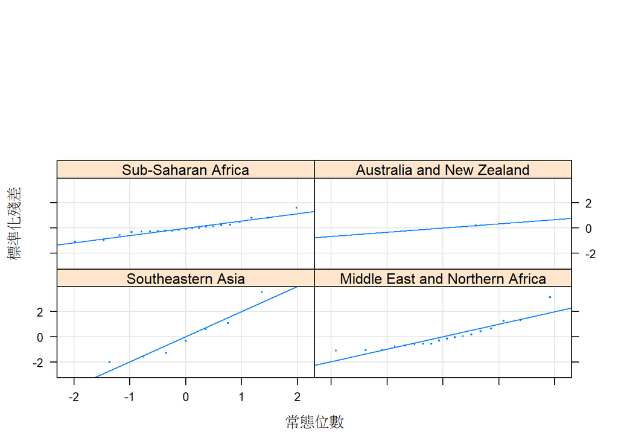

```r
require(lattice)
qqmath(~ scale(resid) |Region , data = fit_m2, type = c('p', 'g', 'r'),
       xlab = '常態位數', ylab = '標準化殘差', layout = c(2, 3),
       pch = '.', cex = 2)
```

###畫預測值與殘差的散佈圖，檢查線性與等分散假設

```r
require(MASS)
```

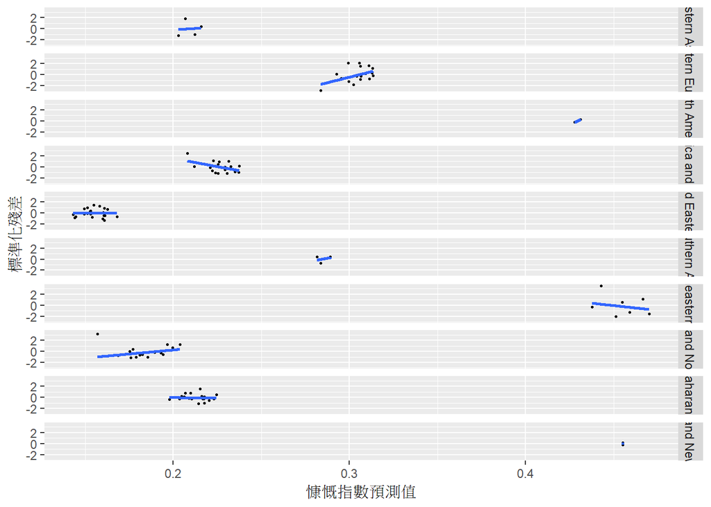

```r
ggplot(data = fit_m2, aes(x = fitted, y = scale(resid), group = Region )) +
  geom_point(pch = 20, size = 1) +
  stat_smooth(method = 'rlm', se = F) +
  facet_grid(Region ~ .) +
  labs(x = '慷慨指數預測值', y = '標準化殘差')
```

### 呈現影響值（影響估計結果過大的值）與標準化殘差

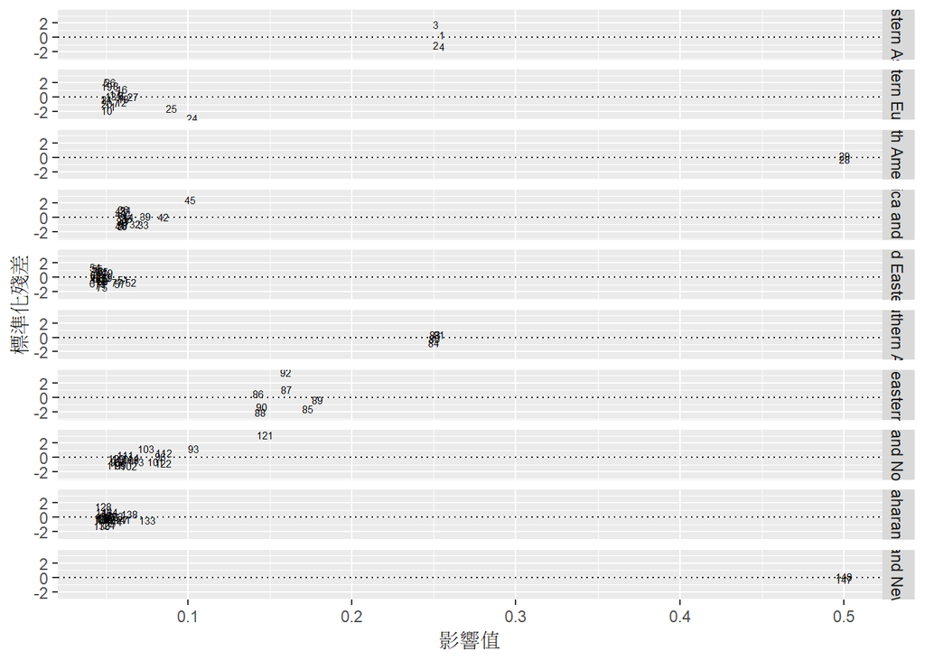

```r
ggplot(data = fit_m2, aes(x = infl, y = scale(resid), group =Region)) +
  geom_text(aes(label = rownames(fit_m2)), cex = 2) +
  geom_hline(yintercept = 0, linetype = 'dotted') +
  facet_grid(Region ~ .) +
  labs(x = '影響值', y = '標準化殘差')
```

#### 可以發現紐澳跟北美的影響值偏高

### 看看影響值

```r
summary(influence(m2)$hat)
```

```
##    Min. 1st Qu.  Median    Mean 3rd Qu.    Max.
## 0.04348 0.05027 0.05893 0.09322 0.07514 0.50035
```

## Part C. 接下來分析資料集當中的其他變項是否和慷慨程度有關

```r
dta_happy <- choose1[, c('Openness','Happiness','GDP','Family','Health','Freedom','Trust' ,'Generosity',
                    'DystopiaResidual')]
```

### 看看基本統計量

```r
colMeans(dta_happy)
```

```
##         Openness        Happiness              GDP           Family
##       28.9322034        5.5755339        0.9229264        1.0275948
##           Health          Freedom            Trust       Generosity
##        0.6785086        0.4450297        0.1513408        0.2390123
## DystopiaResidual
##        2.1111418
```

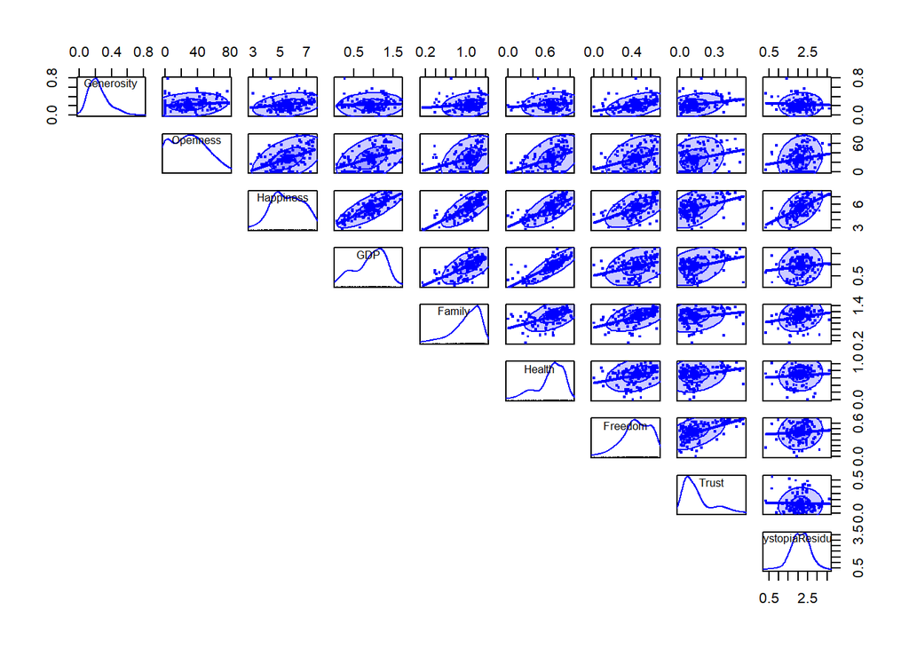

```r
#呈現兩兩散佈圖

require(heplots)
scatterplotMatrix(~ Generosity + Openness + Happiness + GDP+Family+Health+Freedom+Trust+DystopiaResidual, data= choose1,
                  pch = '.', cex = 3, smooth = FALSE, reg.line = FALSE, ellipse = TRUE,
                  diagonal = 'none', lower.panel = NULL)
```

#### 好像有點太小了，捨棄幾個項目好了

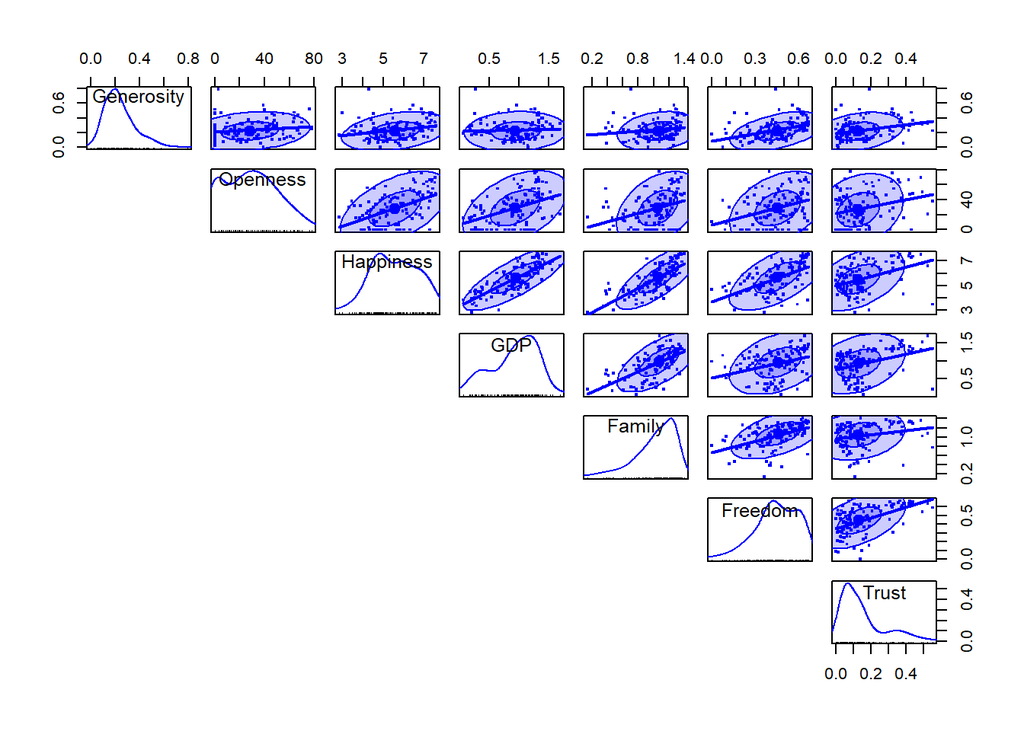

```r
dta_happy1 <- choose1[, c('Openness','Happiness','GDP','Family','Freedom','Trust' ,'Generosity')]
require(heplots)
scatterplotMatrix(~ Generosity + Openness + Happiness + GDP+Family+Freedom+Trust, data= choose1,
                  pch = '.', cex = 3, smooth = FALSE, reg.line = FALSE, ellipse = TRUE,
                  diagonal = 'none', lower.panel = NULL)
```

###畫出各個變量的相關程度(運用corrplot)

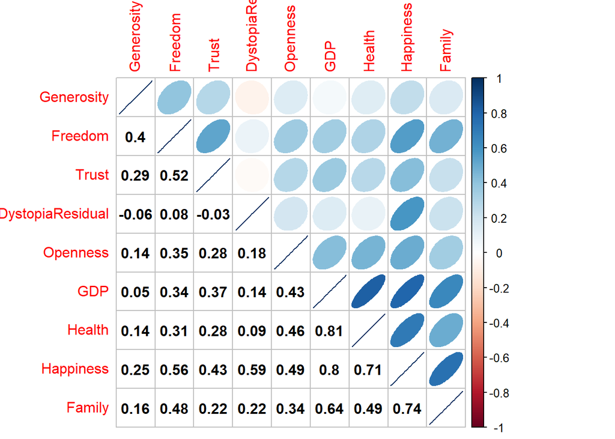

```r
require(corrplot)
corrplot(cor(dta_happy), method = 'ellipse', order = 'hclust', addrect = 4,
         type = 'upper', tl.pos = 'tp')
corrplot(cor(dta_happy), add = TRUE, type = 'lower', method = 'number',
         order = 'hclust', col = 'black', diag = FALSE, tl.pos = 'n', cl.pos = 'n')
```

#### 從圖中可以看見幾個比較有趣的現象。一個國家的GDP其實對慷慨程度沒有很關鍵的影響，說明了不一定是因為衣食豐足才慷慨大方。而跟慷慨呈現最明顯的正向關係的項目是自由~

### 放進三個解釋變項

```r
summary(m4 <- lm(Generosity ~ Freedom + Trust + Happiness, data =dta_happy ))
```

```
##
## Call:
## lm(formula = Generosity ~ Freedom + Trust + Happiness, data = dta_happy)
##
## Residuals:
##      Min       1Q   Median       3Q      Max
## -0.19544 -0.08438 -0.02523  0.06808  0.55639
##
## Coefficients:
##             Estimate Std. Error t value Pr(>|t|)
## (Intercept) 0.084731   0.056853   1.490  0.13889
## Freedom     0.285265   0.096153   2.967  0.00367 **
## Trust       0.110098   0.103269   1.066  0.28862
## Happiness   0.001913   0.011880   0.161  0.87234
## ---
## Signif. codes:  0 '***' 0.001 '**' 0.01 '*' 0.05 '.' 0.1 ' ' 1
##
## Residual standard error: 0.1214 on 114 degrees of freedom
## Multiple R-squared:  0.1667, Adjusted R-squared:  0.1448
## F-statistic: 7.602 on 3 and 114 DF,  p-value: 0.0001115
```

### 看看控制信任與幸福後，自由的效果

```r
summary(m5 <- update(m4, . ~ . - Freedom , data = dta_happy))
```

```
##
## Call:
## lm(formula = Generosity ~ Trust + Happiness, data = dta_happy)
##
## Residuals:
##      Min       1Q   Median       3Q      Max
## -0.21421 -0.08426 -0.01601  0.06232  0.56975
##
## Coefficients:
##             Estimate Std. Error t value Pr(>|t|)
## (Intercept)  0.10929    0.05812   1.880   0.0626 .
## Trust        0.22654    0.09871   2.295   0.0235 *
## Happiness    0.01712    0.01108   1.545   0.1250
## ---
## Signif. codes:  0 '***' 0.001 '**' 0.01 '*' 0.05 '.' 0.1 ' ' 1
##
## Residual standard error: 0.1255 on 115 degrees of freedom
## Multiple R-squared:  0.1024, Adjusted R-squared:  0.08676
## F-statistic: 6.558 on 2 and 115 DF,  p-value: 0.002009
```

```r
anova(m5, m4)
```

```
## Analysis of Variance Table
##
## Model 1: Generosity ~ Trust + Happiness
## Model 2: Generosity ~ Freedom + Trust + Happiness
##   Res.Df    RSS Df Sum of Sq      F   Pr(>F)
## 1    115 1.8105
## 2    114 1.6807  1   0.12977 8.8018 0.003667 **
## ---
## Signif. codes:  0 '***' 0.001 '**' 0.01 '*' 0.05 '.' 0.1 ' ' 1
```

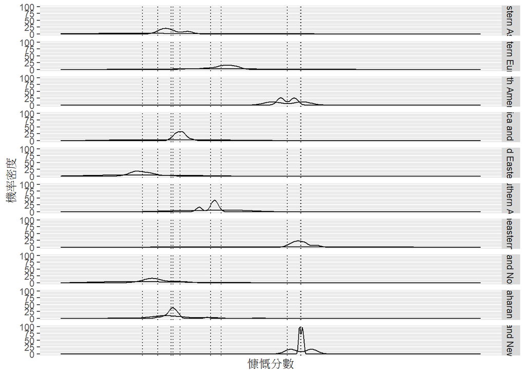

```r
m5 <- lm(Generosity ~ Freedom + Region + Happiness + Trust, data = choose1)
fit_m5 <- data.frame(choose1[, c(10, 8, 2, 4, 9)], fitted = fitted(m5), resid = resid(m5), infl = influence(m5)$hat)

ggplot(data = fit_m5, aes(x = Generosity, group = Region )) +
  stat_density(geom = 'path', position = 'identity') +
  stat_density(geom = 'path', position = 'identity', aes(x = fitted)) +
  geom_vline(xintercept = c(with(choose1, tapply(Generosity, Region, mean))), linetype = 'dotted')+
  facet_grid(Region ~ .) +
  scale_x_continuous(breaks = seq(200, 900, by = 100))+
  labs(x = '慷慨分數', y = '機率密度')
```

#### 看來自由雖然跟慷慨有比較大的正相關性，但是還是無法很有力的左右慷慨的分布。

# 結論

#### 綜觀上面的統計與分析，可以得到一些讓我出乎意料的結果。例如:慷慨的國家不一定幸福，幸福的人不一定願意助人，聽起來真是有點糟糕。不過也看到有些地區，例如東南亞的幸福指數雖然不高，經濟狀況也不是頂尖，但是相較於其他國家卻是更樂於助人的，真是令人敬佩!而自由跟慷慨之間的正相關是最明顯的，顯然這兩個具有開闊氣息的名詞果然是相依相隨的。